# U1L3 - Clustering

## Front Matter

```r
#Delete all objects from Environment - Use with caution
remove(list = ls())

#Load Libraries
library(tidyverse)
library(mvtnorm) #used for randomly generating data from multivariate normal
library(factoextra)
library(gridExtra)
```

```r
#Load Datasets
WBC <- read.csv("/home/maple/CodeProjects/Statistics/STAT508/sample_data/L03_WBC.csv")
#WBC <- read.csv("~/Library/CloudStorage/OneDrive-ThePennsylvaniaStateUniversity/PSU/Teaching/STAT508/Lectures/Data/L03_WBC.csv")
```

## Example - Simulate 2D Dataset

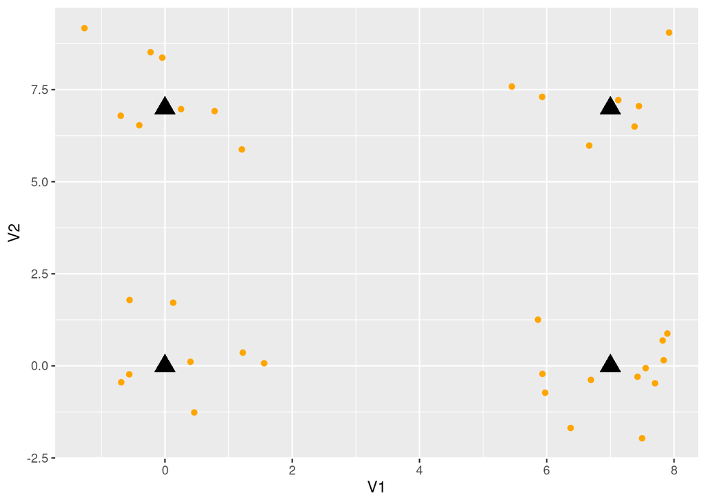

```r
#Create data frame with true centroids
true_centroids <- matrix(c(0, 7, 0 ,7, 0, 0, 7, 7), ncol = 2, byrow = FALSE)

#Randomly generate a dataset (requires mvtnorm package for rmvnorm function)
set.seed(123) #set random number seed so that we all get the the same "random" values
clust1 <- rmvnorm(8, mean = true_centroids[1, ], sigma = diag(2))
clust2 <- rmvnorm(12, mean = true_centroids[2, ], sigma = diag(2))
clust3 <- rmvnorm(8, mean = true_centroids[3, ], sigma = diag(2))
clust4 <- rmvnorm(7, mean = true_centroids[4, ], sigma = diag(2))
set.seed(NULL)

df <- as.data.frame(rbind(clust1, clust2, clust3, clust4))
remove(clust1, clust2, clust3, clust4)

#Plot the dataset
Toy_2DKmeansRraw <-
  ggplot(data = df, mapping = aes(x = V1, y = V2)) +
  geom_point(color = "orange") +
  geom_point(data = as.data.frame(true_centroids),
             color = "black", size = 5, shape = 17)

Toy_2DKmeansRraw
```

## Example - K-means on Simulated Dataset Using K = 4

### Part a - Implement K-means

```r
#Run k-means
set.seed(123)
kmeansRes4c <- kmeans(x = df, centers = 4, iter.max = 10, nstart = 15)
#View Results
kmeansRes4c
```

```
## K-means clustering with 4 clusters of sizes 7, 8, 12, 8
##
## Cluster means:
##           V1         V2
## 1  6.8457457  7.2408963
## 2  0.2463245  0.2627603
## 3  7.0475929 -0.2363717
## 4 -0.0487980  7.3930540
##
## Clustering vector:
##  [1] 2 2 2 2 2 2 2 2 3 3 3 3 3 3 3 3 3 3 3 3 4 4 4 4 4 4 4 4 1 1 1 1 1 1 1
##
## Within cluster sum of squares by cluster:
## [1] 10.27257 12.50800 17.27294 13.58294
##  (between_SS / total_SS =  94.2 %)
##
## Available components:
##
## [1] "cluster"      "centers"      "totss"        "withinss"     "tot.withinss"
## [6] "betweenss"    "size"         "iter"         "ifault"
```

### Part b - Find the number of observations assigned to each cluster

```r
# view cluster assignments

table(kmeansRes4c$cluster)
```

```
##
##  1  2  3  4
##  7  8 12  8
```

### Part c - Compare estimated centroids to true centroids

```r
#Estimated Centroids
kmeansRes4c$centers
```

```
##           V1         V2
## 1  6.8457457  7.2408963
## 2  0.2463245  0.2627603
## 3  7.0475929 -0.2363717
## 4 -0.0487980  7.3930540
```

```r
#True Centroids (created when simulating data)
true_centroids
```

```
##      [,1] [,2]
## [1,]    0    0
## [2,]    7    0
## [3,]    0    7
## [4,]    7    7
```

### Part d - Plot the cluster assignments

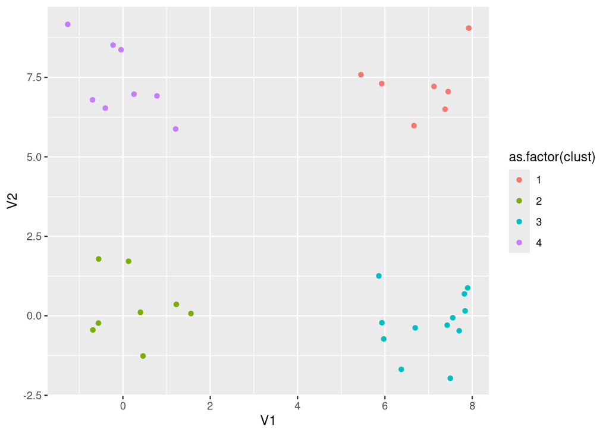

```r
#Create a data frame that has the coordinates and the cluster assignments
df2 <- df%>% mutate(clust = kmeansRes4c$cluster)
#Create visualization
ggplot(df2, aes(V1, V2, color = as.factor(clust))) + geom_point()
```

### Part e - Extract within-cluster variation for each cluster

```r
kmeansRes4c$withinss
```

```
## [1] 10.27257 12.50800 17.27294 13.58294
```

### Part f - Extract total within-cluster variation

```r
kmeansRes4c$tot.withinss
```

```
## [1] 53.63646
```

## Example - K-means on Simulated Dataset Using K = 3

### Part a - Perform K-means with K=3 and visualize the result

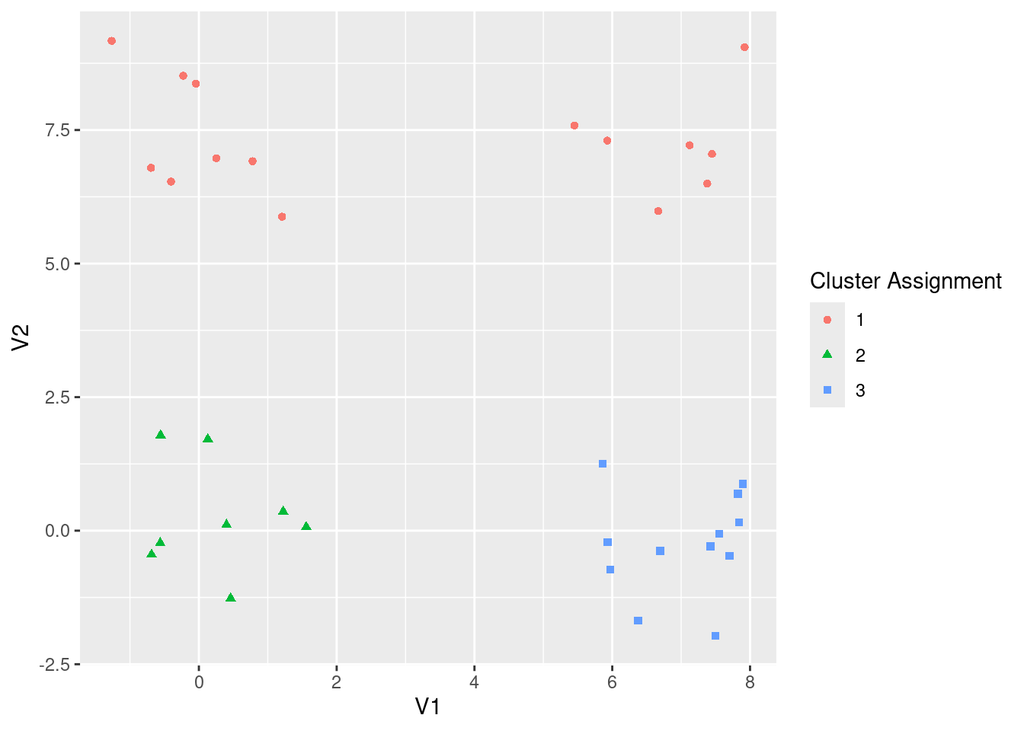

```r
set.seed(123)
kmeansRes3c <- kmeans(x = df, centers = 3, iter.max = 10, nstart = 15)
set.seed(NULL)


#Create a data frame that has the coordinates and the cluster assignments
df2 <-
  df %>%
  mutate(cluster = kmeansRes3c$cluster)

#Create visualization
ggplot(data = df2, mapping = aes(x = V1, y =V2,
                                 color = as.factor(cluster),
                                 shape = as.factor(cluster))) +
  geom_point() +
  labs(color = "Cluster Assignment",
       shape = "Cluster Assignment")
```

### Part b - Compare Total Within-cluster Variation Values between K=3 and K=4

```r
#Within-cluster variation (K=4)
kmeansRes4c$withinss
#Within-cluster variation (K=3)
kmeansRes3c$withinss

#Total Within-cluster Variation (K=4)
kmeansRes4c$tot.withinss
#Total Within-clustere Variation (K=3)
kmeansRes3c$tot.withinss
```

[output not shown]

## Example - Creating Elbow Plot for K-means Using a Function and Picking K

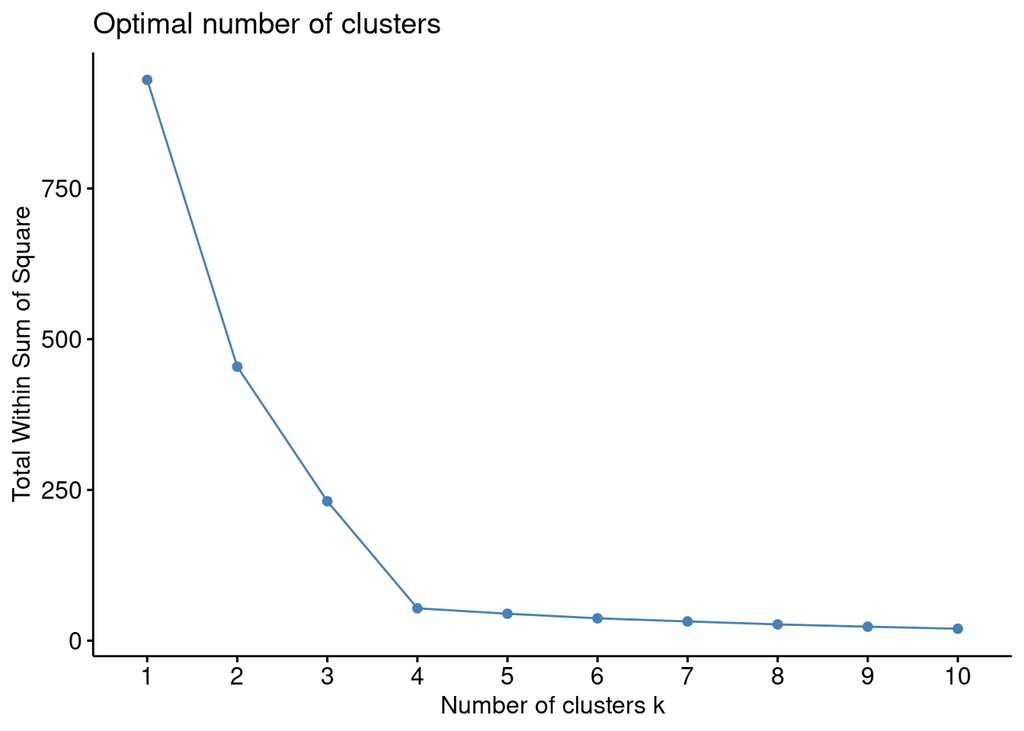

```r
#Use built in function from factoextra
fviz_nbclust(x = df, FUNcluster = kmeans,
             method = "wss", k.max = 10,
             nstart = 15)
```

## Example - Creating Elbow Plot for K-means Using a Loop and Picking K

```r
#Initialize
maxK <- 10
totalWSS_vec <- rep(NA, maxK) #Repeats NA maxK times and stores as vector totalWSS_vec

#Loop for Perfoming K-means for different values of K
for(i in 1:maxK){
  #Do k means
  set.seed(123)
  temp_kmeans <- kmeans(x = df, centers = i, nstart = 15, iter.max  = 10)
  set.seed(NULL)

  #Extra total WSS
  totalWSS_vec[i] <- temp_kmeans$tot.withinss

  print(i)
}
```

```
## [1] 1
## [1] 2
## [1] 3
## [1] 4
## [1] 5
## [1] 6
## [1] 7
## [1] 8
## [1] 9
## [1] 10
```

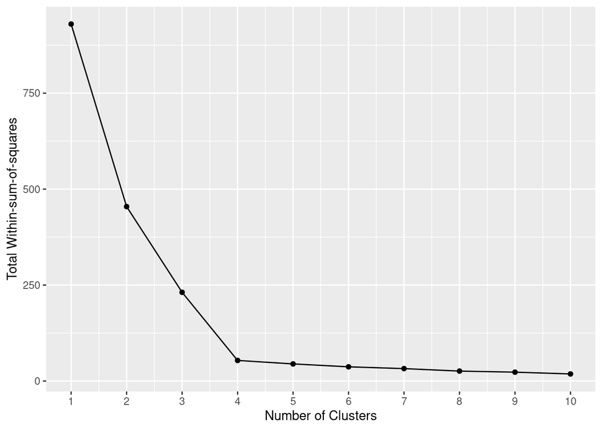

```r
#Create a data frame for plotting
temp_df <- data.frame(K = 1:maxK, TotalWSS = totalWSS_vec)

#Create Plot
ggplot(data = temp_df, mapping = aes(x = K, y = TotalWSS)) +
  geom_point() +
  geom_line() +
  labs(x = "Number of Clusters",
       y = "Total Within-sum-of-squares") +
  scale_x_continuous(breaks = 1:10, limits = c(1, 10))
```

## Example - Hierarchical Clustering on Simulated Dataset

### Part a - Hierarchcial clustering using Euc. distance and single linkage

```r
#Calculate dissimilarity using dist
eucDist <- stats::dist(x = df, method = "euclidean")

#Perform hierarchical clustering

hcSing <- hclust(d = eucDist, method = "single")
```

### Part b - Create a dendrogram of single linkage results

```
## Ignoring unknown labels:
## • subtitlee : "Single Linkage"
```

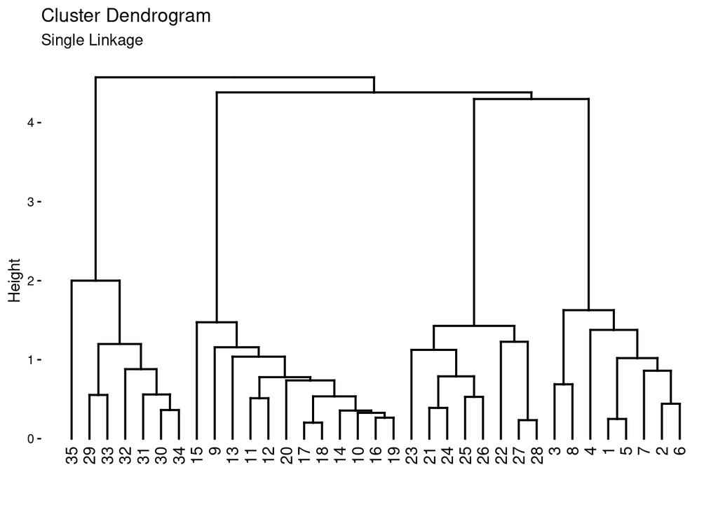

```r
fviz_dend(x = hcSing) +
  labs(subtitlee = "Single Linkage")
```

### Part c - Modify the dendrogram to illustrate 4 clusters

```
## Ignoring unknown labels:
## • subtitlee : "Single Linkage"
```

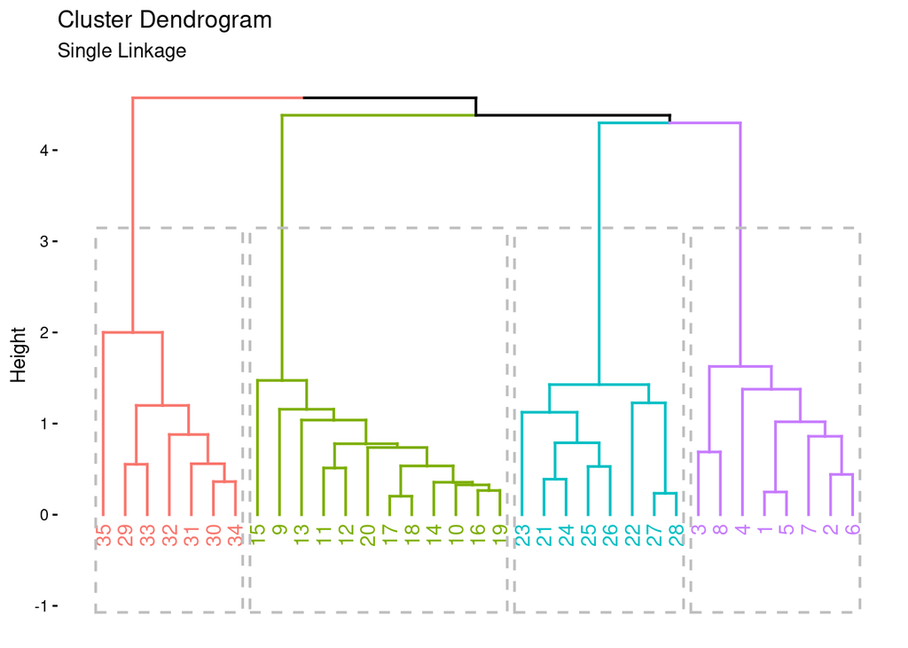

```r
fviz_dend(x = hcSing, k = 4, rect = TRUE) +
  labs(subtitlee = "Single Linkage")
```

### Part d - Extract cluster assignments

```r
#Extract cluster assignments
hcSingClust <- cutree(tree = hcSing, k = 4)

#Add the cluster assignments to df and store the result as a new dataset df2
df2 <-
  df %>%
  mutate(hcCluster = hcSingClust)
```

### Part e - Complete linkage dendrogram for simulated dataset

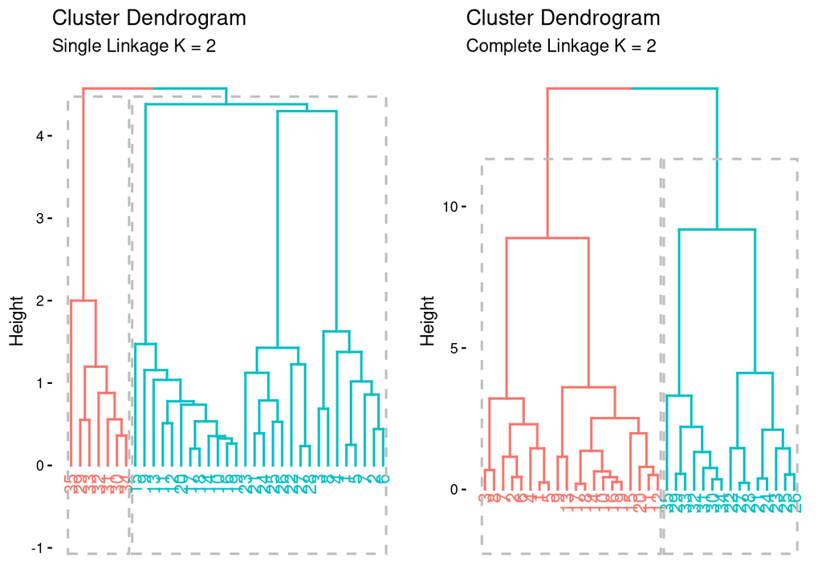

```r
#Create Dendrogram with 2 Clusters using Single Linkage
SinDen2 <-
  fviz_dend(x = hcSing, k = 2 , rect = TRUE) +
  labs(subtitle = "Single Linkage K = 2")


#Calculate dissimilarity using dist
eucDist <- stats::dist(x = df, method = "euclidean")

#Perform hierarchical clustering using Complete linkage
hcComp <- hclust(d = eucDist, method = "complete")

#Create Dendrogram with 2 Clusters using Complete Linkage
ComDen2 <-
  fviz_dend(x = hcComp, k = 2, rect = TRUE) +
  labs(subtitle = "Complete Linkage K = 2")

#Plot the dendrograms side-by-side
grid.arrange(SinDen2, ComDen2, ncol=2)
```

### Part f - Elbow plot for single linkage hierarchical clustering

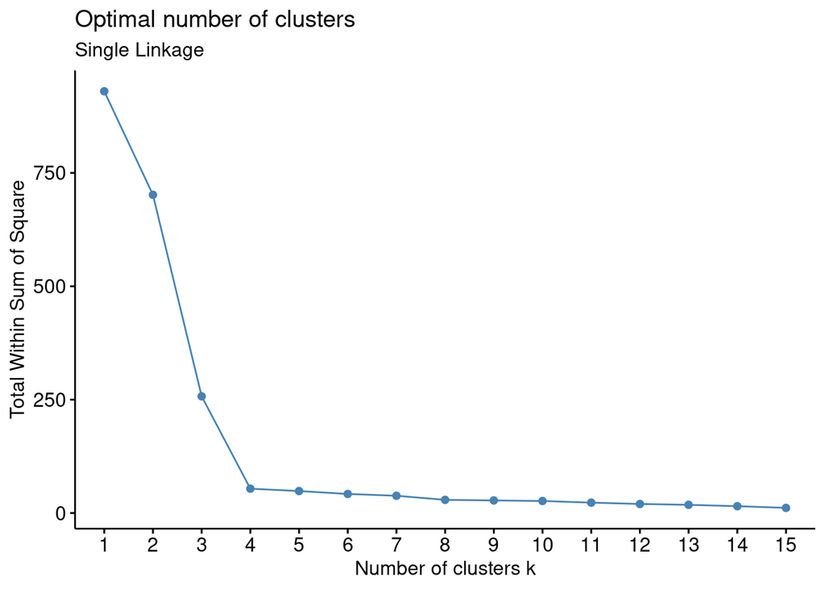

```r
fviz_nbclust(x = df,
             FUNcluster = hcut,
             method = "wss",
             k.max = 15,
             hc_func = "hclust",
             hc_metric = "euclidean",
             hc_method = "single") +
  labs(subtitle ="Single Linkage")
```

## Example - K-means on WBC Data

### Part a - Subset the data

```r
#Subset the data by removing the id and diagnosis variables
wbcNum <- WBC %>% select(-id, -diagnosis)
```

### Part b - Find the variance of the numeric variables

```r
#Find the variance of each numeric variable
(round(apply(X = wbcNum, MARGIN = 2, FUN = var), digits = 3))
```

```
##             radius_mean            texture_mean          perimeter_mean
##                  12.419                  18.499                 590.440
##               area_mean         smoothness_mean        compactness_mean
##              123843.554                   0.000                   0.003
##          concavity_mean     concave.points_mean           symmetry_mean
##                   0.006                   0.002                   0.001
##  fractal_dimension_mean               radius_se              texture_se
##                   0.000                   0.077                   0.304
##            perimeter_se                 area_se           smoothness_se
##                   4.088                2069.432                   0.000
##          compactness_se            concavity_se       concave.points_se
##                   0.000                   0.001                   0.000
##             symmetry_se    fractal_dimension_se            radius_worst
##                   0.000                   0.000                  23.360
##           texture_worst         perimeter_worst              area_worst
##                  37.776                1129.131              324167.385
##        smoothness_worst       compactness_worst         concavity_worst
##                   0.001                   0.025                   0.044
##    concave.points_worst          symmetry_worst fractal_dimension_worst
##                   0.004                   0.004                   0.000
```

### Part c - Standardize the numeric variables

```r
#Standardize the data
wbcScaled <- scale(x = wbcNum, center = TRUE, scale = TRUE)
```

### Part d - Use K-means and determine the optimal number of clusters

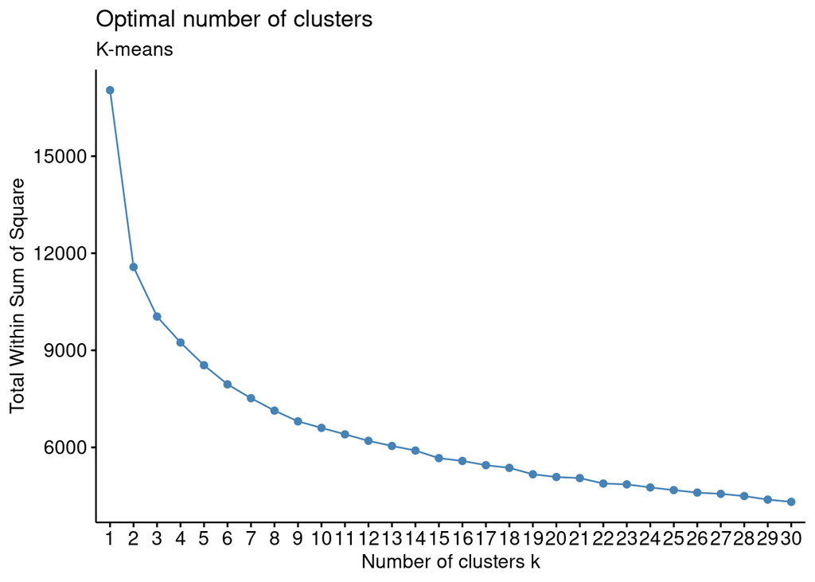

```r
set.seed(123)
fviz_nbclust(x = wbcScaled, FUNcluster = kmeans, method = "wss",
             k.max = 30,
             nstart = 25,
             iter.max = 20) +
  labs(subtitle = "K-means")
```

Interpretation of Plot

- It is not obvious how many clusters should be used. Remember, we look for the elbow. We hope to see a large drop followed by a leveling off of the curve.
- There is a large drop as we go from K = 1 to K = 2, which suggest 2 clusters is likely a better option than 1 cluster.
- There is a smaller but still sizable drop as we go from 2 to 3 clusters.
- The decrease in Total WSS is smaller yet, but maybe still sizable, as we go from 3 to 4 and 4 to 5.
- As we go from 5 to 6 and beyond, the decreases become steadily smaller which suggests a leveling off off of the plot.
- Based on this interpretation, I might consider values of K ranging from 2 to 5.

## Example - PCA on WBC Data

```r
#Perform PCA on standardized data (name result wbcPCA)
wbcPCA <- prcomp(x = wbcScaled, center = TRUE, scale. = TRUE)
#Calculate PVE (used in future plots)
# portion of variance explained.
PVE <- wbcPCA$sdev^2/sum(wbcPCA$sdev^2)
round(PVE, digits = 3)
```

```
##  [1] 0.443 0.190 0.094 0.066 0.055 0.040 0.023 0.016 0.014 0.012 0.010 0.009
## [13] 0.008 0.005 0.003 0.003 0.002 0.002 0.002 0.001 0.001 0.001 0.001 0.001
## [25] 0.001 0.000 0.000 0.000 0.000 0.000
```

## Example - Connecting PCA and K-means

### Part a - Create PCA visualization coded by diagnosis

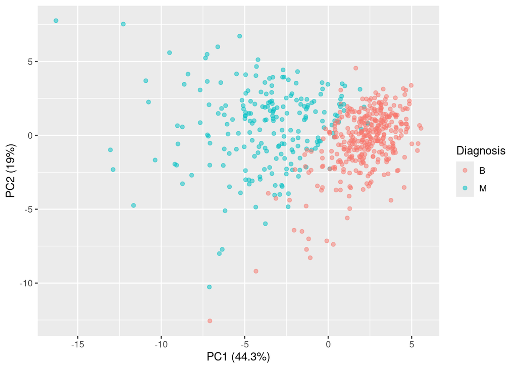

```r
#Create a data frame (for use in ggplot) that has PC scores for 1st 2 PC's
temp_df <- as.data.frame(x = wbcPCA$x[, 1:2])
#Add diagnosis to the plotting dataset (temp_df)
temp_df <- temp_df %>% mutate(diagnosis = WBC$diagnosis)
#Create Plot
ggplot(data = temp_df, aes (x = PC1, y = PC2, color = diagnosis)) +
  geom_point(alpha = .5) +
  labs(x = paste("PC1 (", round(100*PVE[1], digits = 1), "%)", sep = ""),
       y = paste("PC2 (", round(100*PVE[2], digits = 1), "%)", sep = ""),
       color = "Diagnosis")
```

Some thoughts:

- Patients with larger PC1 scores are diagnosed with benign masses
- Patients with small (i.e., the more negative) PC1 scores are diagnosed with malignant masses.
- There is a small region in which patient diagnoses overlap; however, the diagnoses are pretty well separated.
- We may want to look at the loadings to determine which variables heavily affect PC1. They might be good predictors of whether a patient’s mass is benign or malignant.

## Part b - Perform K-means with K = 2; Create PCA visualization coded by cluster assignments

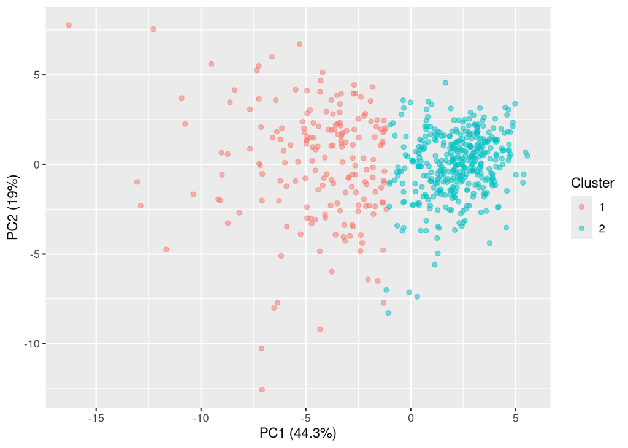

```r
#Perform K-means with 2 clusters
set.seed(123)
kmeansRes2c <- kmeans(x = wbcScaled, centers = 2, iter.max = 20, nstart = 25)
#Add cluster assignment to the plotting dataset (temp_df)
temp_df <- temp_df %>% mutate(cluster = kmeansRes2c$cluster)
#Create Plot
ggplot(data = temp_df, aes (x = PC1, y = PC2, color = as.factor(cluster))) +
  geom_point(alpha = .5) +
  labs(x = paste("PC1 (", round(100*PVE[1], digits = 1), "%)", sep = ""),
       y = paste("PC2 (", round(100*PVE[2], digits = 1), "%)", sep = ""),
       color = "Cluster")
```

Some thoughts:

- It looks like our clusters are somewhat similar to the diagnosis groups, but the clusters are not a perfect representation of the diagnosis groups.

### Part c - Create two-way table comparing cluster assignments and diagnoses

```r
table(temp_df$diagnosis, temp_df$cluster)
```

```
##
##       1   2
##   B  14 343
##   M 175  37
```

Observations:

- In cluster 1, 175 of the 189 patients (92.6%) had a malignant breast mass (diagnosis = M).
- In cluster 2, 343 of the 380 patients (90.3%) had a benign breast mass (diagnosis = B).
- The clusters appear to represent the two diagnosis groups pretty well.

## Example - Hierarchical Clustering on WBC Data

### Part a - Perform hierarchical clustering using Euclidean distance and complete linkage

```r
#Calculate dissimilarity using dist
eucDist <- stats::dist(x = wbcScaled, method = "euclidean")

#Perform hierarchical clustering
hcComp <- hclust(d = eucDist, method = "complete")
```

### Part b - Create dendrogram for complete linkage with 2 clusters

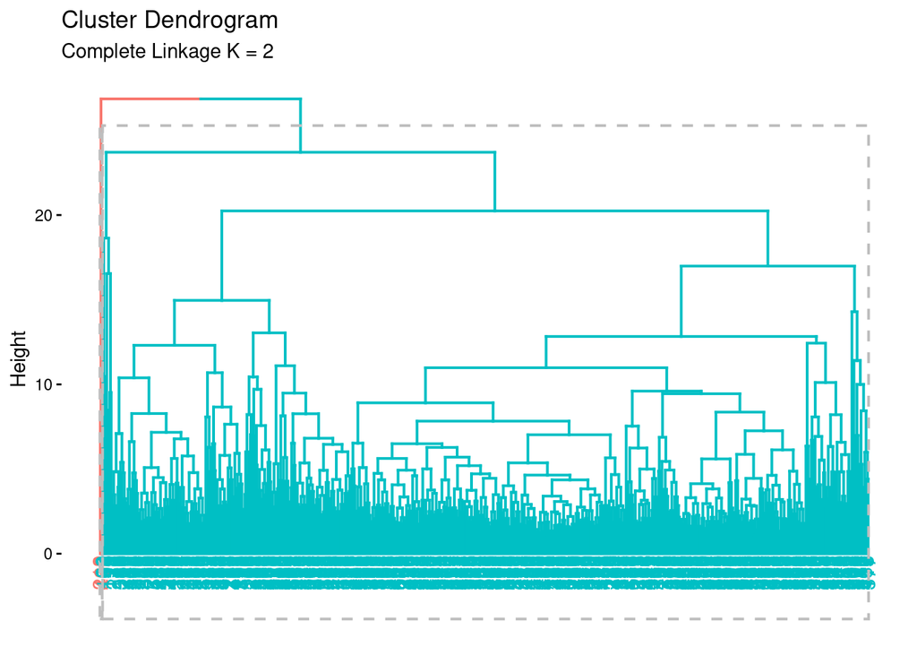

```r
#Create dendrogram
  fviz_dend(x = hcComp, k = 2, rect = TRUE) +
  labs(subtitle = "Complete Linkage K = 2")
```

Thoughts:

- The clusters are not really meaningful.
- One cluster has 2 observations, which might be outliers that are not really close to the other patients.
- The other cluster has 567 out of 569 total patients. We did not really cluster the data.

### Part c - How many clusters should you use?

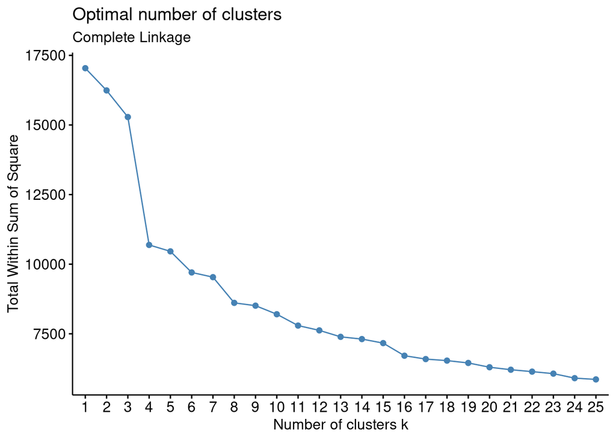

```r
#Elbow Plot
fviz_nbclust(x = wbcScaled, FUNcluster = hcut,
             method = "wss",
             k.max = 25,
             hc_func = "hclust",
             hc_metric = "euclidean",
             hc_method = "complete") +
  labs(subtitle = "Complete Linkage")
```

I would likely use 4 clusters based on this plot.

### Part d - Create two-way table comparing cluster assignments and diagnoses

```r
table(WBC$diagnosis,cutree(hcComp, k = 4))
```

```
##
##       1   2   3   4
##   B  12   2 343   0
##   M 165   5  40   2
```

Observations:

- We discover two large clusters that are similar in terms of size and composition to the two clusters discovered by K-means.
- The other two clusters are relatively small (with sizes of 7 and 2). These smaller clusters might capture some of that patients that might be considered outliers who do not fit closely with the other groups. It might be advantageous to put them into small clusters rather than forcing them into the larger clusters.

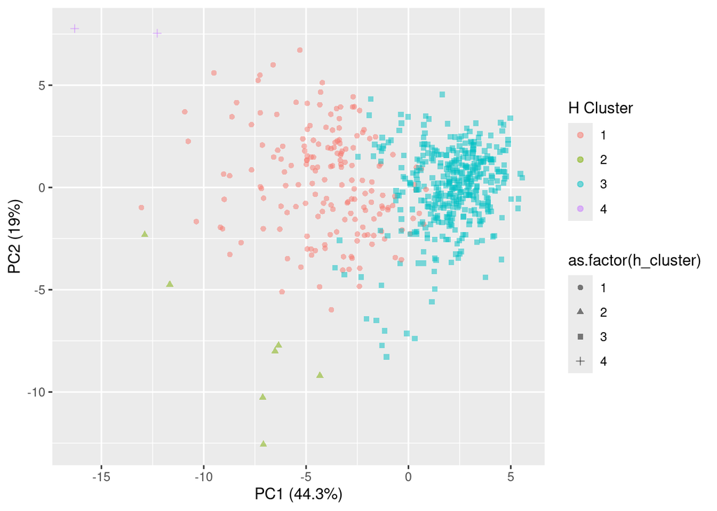

```r
temp_df <- temp_df %>% mutate(h_cluster = cutree(hcComp, k = 4))
#Create Plot
ggplot(data = temp_df, aes (x = PC1, y = PC2, color = as.factor(h_cluster),
                            shape = as.factor(h_cluster))) +
  geom_point(alpha = .5) +
  labs(x = paste("PC1 (", round(100*PVE[1], digits = 1), "%)", sep = ""),
       y = paste("PC2 (", round(100*PVE[2], digits = 1), "%)", sep = ""),
       color = "H Cluster")
```